# Der Effekt von Earnings-Conference Calls am Aktienmarkt

# Motivation

Earnings Conference Calls sind zentrale Informationsereignisse in Finanzmärkten. Hier kommuniziert das Management direkt mit Investoren und Analysten über die aktuelle Geschäftslage und Zukunftsaussichten. Die finanzwirtschaftliche Forschung zeigt, dass diese Calls erhebliche Kursbewegungen auslösen können - doch die zugrundeliegenden Mechanismen sind noch nicht vollständig verstanden.

Während traditionelle Finanztheorie von effizienten Märkten ausgeht, die alle verfügbaren Informationen sofort verarbeiten, zeigen empirische Studien, dass die Art der Kommunikation und das Sentiment der Aussagen eigenständige Erklärungskraft für Aktienkursreaktionen besitzen. Diese Erkenntnisse haben direkte praktische Relevanz: Banken nutzen Sentiment-Analysen für algorithmische Handelsstrategien, Hedge Fonds entwickeln systematische Ansätze zur Textauswertung, und Asset Manager integrieren qualitative Informationen in ihre Bewertungsmodelle.

In diesem Projekt kombinieren Sie Event Studies - eine etablierte Methode der empirischen Finanzforschung zur Messung von Informationseffekten - mit modernen Large Language Models zur systematischen Textanalyse. Sie untersuchen, ob und wie sich qualitative Aussagen des Managements in quantifizierbaren Marktreaktionen niederschlagen, und lernen dabei sowohl die methodischen Grundlagen der Kausalitätsidentifikation als auch den praktischen Umgang mit KI-gestützten Finanzanalysen kennen.

# Event-Study-Methodik und theoretische Diskussion

1. Lesen Sie das Kapitel [“Event Studies” in Huntington-Klein (2021)](https://theeffectbook.net/ch-EventStudies.html) und beantworten Sie die folgenden Fragen dazu:

Kann eine Eventstudie helfen, den kausalen Effekt eines Earnings Conference Calls auf die Aktienrendite eines Unternehmens zu identifizieren? Gehen Sie bei der Beantwortung dieser Frage insbesondere auf die nachfolgenden Punkte ein:

- Welche Art von Variation nutzt eine Eventstudie zur Identifikation des Effekts?
- Welche Voraussetzung(en) müssen erfüllt sein, damit die Eventstudie eine gültige Kausalschätzung liefert?
  - Was bedeutet das “Joint-Test Problem” in diesem Kontext?

**Kann eine Eventstudie helfen, den kausalen Effekt eines Earnings Conference Calls auf die Aktienrendite eines Unternehmens zu identifizieren?**

Ja, eine Eventstudie kann grundsätzlich dazu verwendet werden, den kausalen Effekt eines Earnings Conference Calls (ECC) auf die Aktienrendite eines Unternehmens zu identifizieren. Dabei handelt es sich um ein etabliertes Verfahren in der empirischen Finanzforschung, das darauf abzielt, die kurzfristige Marktreaktion auf ein exogenes Ereignis – wie etwa die Veröffentlichung von Quartalszahlen und deren verbale Kommunikation im Rahmen eines Earnings Calls – zu messen. Damit dieses Verfahren jedoch zu einer gültigen Kausalschätzung führt, müssen zentrale methodische Voraussetzungen beachtet werden.

**Genutzte Variation: Vorher-Nachher-Vergleich innerhalb einer Einheit**

Eventstudien nutzen zeitliche Variation innerhalb eines Unternehmens, um den Effekt des Ereignisses zu identifizieren. Der zentrale Gedanke besteht darin, dass ein klar datierbares Ereignis – wie der Zeitpunkt des Earnings Calls – den Beginn einer Behandlung markiert. Man vergleicht die Entwicklung der Zielgröße (hier: Aktienrendite) vor dem Ereignis mit der Entwicklung nach dem Ereignis.

Diese Vorher-Nachher-Vergleiche beruhen auf der Annahme, dass sich die Entwicklung ohne das Ereignis in ähnlicher Weise fortgesetzt hätte, wie sie zuvor beobachtet wurde. Die Differenz zwischen beobachtetem Ergebnis nach dem Event und der geschätzten kontrafaktischen Entwicklung (also der erwarteten Entwicklung ohne das Event) liefert dann den geschätzten Effekt.

Insbesondere bei Aktienmärkten gilt: Da Informationen schnell eingepreist werden (Effizienzmarkthypothese), manifestieren sich Wirkungen typischerweise sofort nach Bekanntwerden der Information – also am oder unmittelbar nach dem Tag des Earnings Calls.

**Voraussetzungen für eine gültige Kausalschätzung**

Damit eine Eventstudie als glaubwürdiger Ansatz zur Identifikation eines kausalen Effekts dienen kann, müssen mehrere wichtige Annahmen erfüllt sein:**

*1. Keine gleichzeitigen Störeinflüsse (Konfundierung)*

Eine zentrale Voraussetzung ist, dass keine anderen Ereignisse zeitgleich mit dem Earnings Call auftreten, die ebenfalls die Aktienrendite beeinflussen könnten. Denn dann wäre nicht eindeutig, ob die beobachtete Kursreaktion auf den Earnings Call oder auf das andere Ereignis zurückzuführen ist. Solche gleichzeitigen Einflüsse stellen einen Backdoor-Pfad im kausalen Diagramm dar und gefährden die Identifikation des Effekts.

*2. Gültiges Kontrafaktum (Counterfactual)*

Die Eventstudie basiert auf der Annahme, dass man eine plausible Prognose für den Verlauf der Rendite ohne das Ereignis treffen kann. Dazu nutzt man entweder:

- konstantes Mittel der Vorperioden (Mean Adjusted Return),
- eine Entwicklung, die durch Marktrenditen approximiert wird (Market Adjusted Return),
- oder eine risikoadjustierte Prognose auf Basis eines Regressionsmodells (z. B. CAPM oder Fama-French-Modell).

Je präziser dieses Kontrafaktum ist, desto glaubwürdiger ist die Interpretation der Abweichung als kausaler Effekt.

*3. Kurzes Beobachtungsfenster*

Da Märkte vielen Einflüssen unterliegen, ist es empfehlenswert, den Analysezeitraum möglichst kurz zu halten – z. B. [-1, +1] oder [-2, +2] Handelstage rund um den Earnings Call. So wird die Wahrscheinlichkeit minimiert, dass andere Faktoren in die Kursentwicklung hineinwirken.

*4. Keine Antizipation oder Verzögerung*

Die Wirkung des Earnings Calls sollte nicht bereits vor dem Ereignis sichtbar sein (z. B. durch Leaks oder vorab veröffentlichte Informationen). Ebenso sollten mögliche Effekte zeitnah nach dem Ereignis eintreten, damit sie klar dem Ereignis zugeordnet werden können.

**Das Joint-Test Problem**

Eine zentrale methodische Herausforderung in der Eventstudienmethodik ist das sogenannte Joint-Test Problem. Es beschreibt die Tatsache, dass jede Eventstudie zwei Hypothesen gleichzeitig testet:

Ob das untersuchte Ereignis (z. B. der Earnings Call) tatsächlich einen kausalen Effekt auf die Aktienrendite hat, und ob das zur Schätzung des Kontrafaktums verwendete Modell korrekt spezifiziert ist.

Ein signifikanter Unterschied zwischen tatsächlicher Rendite und der geschätzten Kontrafaktischen kann daher sowohl auf einen tatsächlichen Ereigniseffekt zurückgehen – als auch auf ein fehlerhaftes Prognosemodell. Die Interpretation des Effekts ist also nur dann zulässig, wenn das verwendete Modell den Verlauf ohne Ereignis korrekt vorhergesagt hätte.

Ein Beispiel: Wird fälschlich angenommen, dass die Rendite vor dem Earnings Call konstant war, obwohl sie einem Trend folgte, wird die Veränderung nach dem Call über- oder unterschätzt.

*Umgang mit dem Joint-Test Problem*

Ein gängiger methodischer Ansatz zur Milderung des Joint-Test Problems ist der Einsatz von Placebo-Tests. Dabei wird dieselbe Eventstudien-Logik auf Zeitpunkte oder Unternehmen angewandt, bei denen kein tatsächliches Ereignis stattgefunden hat. Zeigt sich auch hier ein signifikanter Effekt, ist das ein Hinweis darauf, dass das Kontrafaktummodell ungeeignet ist – also systematisch fehlerhafte Prognosen liefert.

**Fazit**

Die Eventstudie ist ein elegantes und mächtiges Instrument zur Schätzung von Kausaleffekten bei punktuell auftretenden, klar datierbaren Ereignissen wie Earnings Conference Calls. Sie nutzt die zeitliche Veränderung innerhalb einer Einheit zur Identifikation des Effekts und kann – unter Einhaltung zentraler methodischer Voraussetzungen – zu belastbaren Ergebnissen führen.

Entscheidend ist jedoch: Nur wenn keine gleichzeitigen Störeinflüsse vorliegen und das Prognosemodell des Kontrafaktums glaubwürdig ist, kann der Unterschied zwischen Vorher- und Nachherperiode als kausaler Effekt interpretiert werden. Das Joint-Test Problem erinnert dabei daran, dass jede Eventstudie zugleich ein Test für die Modellqualität ist – und damit besonders sorgfältig geplant und validiert werden muss.

# Daten und Datenaufbereitung

## Finanzmarktkennzahlen

2. Sie sollten in einem ersten Schritt Finanzkennzahlen aus Datastream herunterladen. Insbesondere sollten Sie den Return Index (RI) und die Total Assets (WC02999) für alle Firmen im Euro Stoxx 600 Technology Index ( wir haben Ihnen die RIC Kürzel in der Readme bereitgestellt ) vom 01.01.2020 bis heute extrahieren.

Bitte laden Sie für den Return Index tägliche Daten herunter und für die Total Assets Quartalsdaten. Weiterhin sollten Sie den Total Return Index (RI) des Euro Stoxx 600 (RIC = .STOXX) herunterladen (auch tägliche Daten). Bitte achten Sie darauf alle Daten **in Euro** herunterzuladen.

Achten Sie darauf die RIC als eindeutige Identifikationskennung in ihren Datensatz aufzunehmen.

Das Institut für Finanzwirtschaft der Universität Ulm hat einen ausführlichen [Guide zu Datastream](https://www.uni-ulm.de/fileadmin/website_uni_ulm/allgemein/Update_Introduction_Datastream_May_2025.pdf) erstellt, der Ihnen beim Download der Daten sicherlich helfen kann.

Die Universität Ulm stellt für den Download Remote-PCs zur Verfügung, auf die Sie sich von daheim aus einloggen können. Bitte buchen Sie sich hier einen Slot um Zugriff auf diese PCs zu erhalten: https://www.uni-ulm.de/mawi/iof/lehre/proposals-for-theses/datastream-and-workspace/

Sie sollten ihre Daten in Excel herunterladen und in ihrem Projekt im Unterordner `data` abspeichern.

*Hinweis 1:* Es empfiehlt sich zwei Tabellenblätter im Excel File anzulegen, eines für die täglichen Daten und eines für die Quartalsdaten

*Hinweis 2:* Datastream ist eine Datenbank, die Kennzahlen zur Finanzlage von börsennotierten Unternehmen weltweit beinhaltet. Die Lizenzen zu Datastream an der Universität Ulm werden von der Studienkommission Wirtschaftswissenschaften und der LBBW bezahlt und die Datenbank steht allen WiWi-Studierenden frei zur Verfügung. [Nähere Informationen zu Datastream finden Sie hier](https://www.uni-ulm.de/mawi/iof/lehre/proposals-for-theses/datastream-and-workspace/) (Bitte beachten: Sie müssen im Uninetz (z.B. über VPN) eingeloggt sein um die Informationen zu sehen und um sich auf die Remote-PCs loggen zu können).

*Hinweis 3:* Bei den Total Assets müssen Sie immer das Enddatum des vorherigen Jahres nehmen für den Download, d.h. Start Date wäre 31.12.2019

3. Lesen Sie die Excel Datei, welche Sie in Aufgabe 2 erstellt haben, in R ein. Achten Sie darauf, dass diese Daten tidy und richtig formatiert sind. Joinen Sie die täglichen Daten mit den Quartalsdaten für die relevanten Firmen. Die Quartalsdaten zählen für das komplette Quartal zu dem diese hinzugemerged wurden.

Setzen Sie sich mit den Aktienkursen auseinander und beantworten folgende Fragen: - Sie wollen in Aufgabe 4 *Renditen* berechnen, warum sollten Sie Daten zum “Total Return Index” und nicht dem “Price” oder “Unadjusted Price” herunterladen? Schauen Sie sich zur Klärung dieser Frage den [Guide der Uni Ulm zu Datastream](https://www.uni-ulm.de/fileadmin/website_uni_ulm/allgemein/Update_Introduction_Datastream_May_2025.pdf) genauer an. Diesen Guide sollten sie auch für den Download der Daten heranziehen.

*Hinweis:* In dem tidy Datensatz sollten Sie eine Spalte mit dem Unternehmensidentifier (RIC), eine mit dem Datum und eine mit der Variablen (RI bzw. Total Assets) haben

**Warum sollte für die Renditeberechnung der “Total Return Index” (RI) und nicht der “Price” (P) oder “Unadjusted Price” (UP) verwendet werden?**

Für die Berechnung von Aktienrenditen ist der Total Return Index (RI) die aussagekräftigste Kennzahl, da er im Gegensatz zu einfachen Kursdaten nicht nur die reine Preisveränderung einer Aktie abbildet, sondern auch Dividendenzahlungen und Kapitalmaßnahmen (wie Bezugsrechte, Aktiensplits) berücksichtigt. Damit reflektiert der RI die tatsächliche Wertentwicklung für Investoren unter der Annahme, dass Ausschüttungen sofort reinvestiert werden.

Der in Datastream ebenfalls verfügbare “Price” (P) hingegen ist lediglich der um Kapitalmaßnahmen bereinigte Aktienkurs. Er stellt somit eine „technisch bereinigte“ Kursreihe dar, ignoriert jedoch Dividenden, was in renditebasierten Studien zu systematischen Verzerrungen führen kann – insbesondere bei dividendenstarken Unternehmen.

Noch ungeeigneter ist der “Unadjusted Price” (UP). Dieser enthält keinerlei Korrekturen, weder für Splits noch für andere Kapitalmaßnahmen, und entspricht dem jeweils tatsächlich gehandelten Börsenkurs an einem Tag. Für wissenschaftliche Analysen ist diese Rohreihe nur in Ausnahmefällen sinnvoll, etwa zur Implementierung von Preisfiltern (z.B. Ausschluss von Penny Stocks).

Wie auch der Datastream-Guide der Universität Ulm (2025, S. 14) betont: „Für die meisten Zwecke – etwa die Bestimmung von Volatilitäten oder Investment-Performance – sollte der Total Return Index (RI) verwendet werden.“

Gerade bei Eventstudien, bei denen kurzfristige Marktreaktionen isoliert gemessen werden sollen, ist es essenziell, alle wertrelevanten Komponenten zu erfassen – inklusive Ausschüttungen. Andernfalls würden Renditeberechnungen wichtige Bestandteile der realisierten Wertentwicklung vernachlässigen und zu einer Unterschätzung des tatsächlichen Returns führen.

**Fazit**

Der RI ist der einzige Indikator, der die wirtschaftliche Realität der Anlegererträge vollständig abbildet. Deshalb ist er die methodisch korrekte Grundlage für Renditeanalysen im Rahmen empirischer Kapitalmarktforschung.

## Renditen berechnen

4. In ihrem Datastream-Datensatz, welchen Sie in Aufgabe 2 bereits eingelesen und in Aufgabe 3 bearbeitet haben, sind die *Total Return Indices* (RI) der größten Unternehmen aus der Tech-Branche in Europa enthalten, sowie der *Total Return Indix* des Euro Stoxx 600. Der Euro Stoxx 600 ist ein großer, diversifizierter Aktienindex in Europa in dem die 600 größten Unternehmen gelistet sind. Sie sollten den Euro Stoxx 600 als Benchmark ( Rendite des Marktes ) für ihre betrachteten Unternehmen verwenden. Bitte berechnen Sie in dieser Aufgabe die Tagesrenditen aller Einzelunternehmen als:

$$\begin{equation}
Rendite_{i,t} = \frac{RI_{i,t} - RI_{i,t-1}}{RI_{i,t-1}}
\end{equation}$$

mit i = {jedes Einzelunternehmen im Datensatz} und t = {Tag}

und des Euro Stoxx 600 als:

$$\begin{equation}
Rendite_{m,t} = \frac{RI_{m,t} - RI_{m,t-1}}{RI_{m,t-1}}
\end{equation}$$

mit m = {Euro Stoxx 600} und t = {Tag}

Prüfen Sie auf NA in den Anfangszeilen und entfernen Sie diese.

Speichern Sie die Renditen der jeweiligen Unternehmen in einer neuen Variable `Rendite` ab und die Rendite des Euro Stoxx 600 als `Marktrendite`.

5. In Aufgabe 1 hatten Sie sich bereits mit der Event-Study Methodik beschäftigt, welche Sie im weiteren Verlauf des Projektes anwenden sollen. Ein erster Schritt ist es, sogenannte *Abnormale Renditen* zu berechnen. Dies sollten Sie in dieser Aufgabe mit dem sogenannten Market-adjusted returns model tun. Bitte ziehen Sie dafür die Rendite des Marktindex von der Rendite des einzelnen Unternehmens pro Tag ab.

$$\begin{equation}
AbnormaleRendite_t = Rendite_{i,t} - Rendite_{m,t}
\end{equation}$$

Beantworten Sie dazu folgende Frage:

- Warum ist es nötig die Marktrendite ( $Rendite_{m,t}$ ) von der Rendite der Einzelaktien abzuziehen? Nutzen Sie ihre Erkenntnisse aus Aufgabe 1 zur Beantwortung dieser Frage.

**Warum wird die Marktrendite von der Rendite der Einzelaktien abgezogen?**

Die abnormale Rendite zeigt, ob sich der Kurs einer Aktie stärker oder schwächer entwickelt hat als der Gesamtmarkt. Indem man die Marktrendite vom Unternehmensreturn abzieht, filtert man allgemeine Marktentwicklungen heraus, die nicht unternehmensspezifisch sind.

Das ist notwendig, weil Aktienrenditen oft durch makroökonomische Ereignisse beeinflusst werden, wie z.B. Zinsentscheide, geopolitische Spannungen oder allgemeine Wirtschaftsdaten. Diese wirken auf alle Unternehmen – unabhängig von eigenen Ereignissen wie einem Earnings Call.

Ziel der Eventstudie ist es jedoch, gezielt die Reaktion auf ein spezifisches Ereignis zu messen. Nur wenn man die Marktentwicklung kontrolliert, lässt sich sagen, ob die Kursbewegung durch das Event selbst verursacht wurde.

Die Bereinigung entspricht also genau der Logik aus Aufgabe 1:

Man will die Reaktion auf das Event isolieren – nicht den allgemeinen Markttrend messen.

## Earnings Call-Transkripte von LSEG Workspace einlesen

Die Basis für alle weiteren Analysen sind die Abnormalen Renditen der einzelner Unternehmen, die Sie in den vorherigen Aufgaben berechnet haben. Jedoch benötigen Sie nun noch ein Event, dessen Effekt Sie im Rahmen der Eventstudie analysieren möchten. Hier kommen die bereits in der Motivation erwähnten Earnings-Conference-Calls ins Spiel, die Sie im weiteren Verlauf des Projekts näher analysieren sollten. Die Earnings Conference Calls finden für große Unternehmen in der Regel quartalsweise statt. Manche Unternehmen halten jedoch auch nur halbjährliche Earnings Conference Calls ab und andere verzichten ganz darauf.

6. Wir haben Ihnen die Earnings Conference Calls aus LSEG Workspace für alle Firmen aus dem Euro Stoxx 600 Technology Sektor ab 2020 bis zum aktuellen Rand heruntergeladen und diese unter `data/transcripts.zip` bereitgestellt. Lesen Sie die Dateien in R ein. Ihr Datensatz sollte für jedes Transkript das RIC-Kürzel, Datum und den Text des Transkripts beinhalten, dies können Sie aus dem Namen der Datei extrahieren.

*Hinweis:* Das RIC Kürzel finden Sie im Namen der Datei (Beispiel: “2020-Jan-28-SAPG.DE-140242583050-Transcript.txt” -> “Datum-RIC-Nummer-Transcript.txt”)

Die Earnings Conference Calls laufen immer gleich ab: Zuerst spricht der CEO und meist CFO über die aktuellen Entwicklungen am Markt und wie das Unternehmen aktuell steht. Weiterhin werden Einschätzungen für die Zukunft angesprochen. Im zweiten Teil, der Q&A Sektion, dürfen Analysten Fragen an das Management stellen. Dieser Teil ist meist informativer als die vorbereiteten Statements des Managements, da die Fragen nicht vorher abgesprochen werden und das Management spontane Antworten bereithalten muss.

Sie sollen sich in diesem Projekt auf den zweiten Teil, d.h. die Q&A Section in den Earnings Conference Calls konzentrieren.

7. Analysieren Sie im ersten Schritt die Earnings Conference Calls indem Sie einige davon überfliegen. Schauen Sie explizit nach Hinweisen, ob und wie die Q&A Sektion im Text von den anderen Inhalten abgetrennt ist. Anschließend sollten Sie diese Q&A Sektion in den Earnings Conference Calls in R extrahieren, da Sie nur diese Sektion in den späteren Aufgaben analysieren sollen.

Da es vorteilhaft für ihre weitergehenden Analysen ist möglichst kompakte Texte ohne Redundanzen zu haben, sollten Sie zusätzlich die Definitionen und Disclaimer Sektion am Ende des Earnings Calls entfernen.

*Hinweis 1:* Der Anteil der Q&A Sektion an der Gesamtkonversation liegt in der Regel unter 80%. Für manche Earnings Conference Calls ist dieser Anteil höher, aber hier würde ich empfehlen nachzuschauen, ob Sie die Q&A Sektion richtig extrahiert haben. Manchmal gibt es keine Q&A Sektion, dann sollte dort auch kein Text extrahiert werden.

*Hinweis 2:* Nutzen Sie das Paket `stringr` um Textmanipulationen vorzunehmen. In diesem [Cheatsheet](https://rstudio.github.io/cheatsheets/strings.pdf) sehen Sie die Hauptanwendungen inkl. regulärer Ausdrücke, welche wichtig sind um mit Texten zu arbeiten.

8. Stellen Sie in einer Grafik anschaulich dar, wie viele Worte in einem typischen Earnings Conference Call verwendet werden und wie viel davon die Q&A Sektion einnimmt.

Beschreiben Sie ihre Grafik.

*Hinweis:* Eventuell wollen Sie hier die Verteilungen zeigen o.ä.? Entscheiden Sie selbst, welche Grafik Sie produzieren.

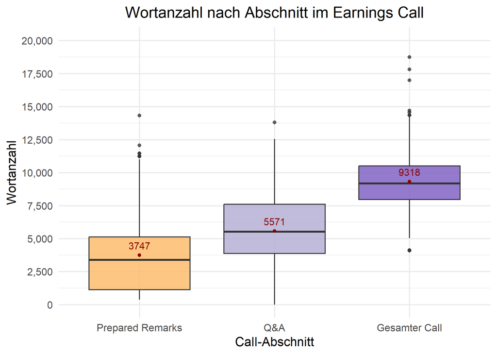

**Wortanzahl nach Abschnitt im Earnings Call**

Zur Untersuchung der inhaltlichen Struktur von Earnings Conference Calls wurde analysiert, wie viele Wörter typischerweise in den einzelnen Abschnitten gesprochen werden. Die Boxplot-Grafik zeigt die Verteilung der Wortanzahl für die drei zentralen Bestandteile eines Calls: Prepared Remarks, Q&A-Sektion und der Gesamte Call.

*Gesamter Call: Umfangreicher Mix aus beiden Abschnitten*

Der gesamte Call kombiniert beide Abschnitte und weist dementsprechend höhere Wortzahlen auf. Der Median liegt hier bei etwa 9.000 Wörtern. Die Verteilung ist ebenfalls breit gefächert, mit vereinzelten Calls, die deutlich über 10.000 Wörter umfassen. Diese hohe Varianz verdeutlicht, dass Earnings Calls in Länge und Tiefe stark variieren können – je nach Unternehmen und Gesprächsverlauf.

**Interpretation der Grafik**

**Fazit**

Earnings Calls folgen keiner festen Struktur, was Länge und Gewichtung der Abschnitte betrifft. Die Q&A-Sektion spielt jedoch in vielen Fällen eine zentrale Rolle und ist daher besonders relevant für textanalytische Auswertungen. Die grafische Darstellung liefert einen prägnanten Überblick über die typischen Muster und hilft, analytische Schwerpunkte gezielt zu setzen.

## Themenkategorien und Sentiment-Scores

Nachdem Sie nun die Earnings Conference Calls in R eingelesen und einen ersten Eindruck von deren Inhalt erhalten haben sollten Sie diese mit einem LLM (konkret mit Google Gemini) analysieren. Dafür sollten Sie einen Zero-Shot Prompt erstellen und mit Hilfe dieses Prompts die Aussage der Q&A Sektionen der Earnings Conference Calls analysieren.

9. Entwickeln Sie einen Zero-Shot Prompt für ein Large Language Model (LLM), der Earnings Conference Call Transcripts analysiert und strukturierte Sentiment-Bewertungen ausgibt. Bitte beachten Sie dabei folgende Punkte:

Zielkategorien:

- Unternehmensperformance (Finanzlage, Wachstumschancen, Unternehmensrisiken)
- Marktumfeld (Branche, Wettbewerb, externe Faktoren)

Output-Format:

- JSON-Struktur mit Sentiment-Scores von -1 (sehr negativ) bis +1 (sehr positiv)
- Keine zusätzlichen Erklärungen oder Markdown-Formatierung

Sie sollten in ihrem Prompt nach einem JSON Output verlangen (strukturiertes Format), welchen Sie mit dem Paket `jsonlite` gut in R verarbeiten können.

*Hinweis 1:* Im Anhang ist eine Erklärung für die Unterschiede zwischen einem Zero-Shot Prompt, einem One-Shot Prompt und einem Few-Shot Prompt

*Hinweis 2:* Wir haben Ihnen ein [Tutorial zusammengestellt](https://projektkurs-data-science-ulm2425.netlify.app/tutorials/zero-prompting), welches das Prompting an einem Beispiel zeigt.

Der Zero-Shot Prompt für unser Large Language Model (LLM), der Earnings Conference Call Transcripts analysiert und strukturierte Sentiment-Bewertungen ausgibt:

’Analysieren Sie den folgenden Ausschnitt aus einem Earnings Call-Transkript und geben Sie strukturierte Sentiment-Werte für: 1. “Unternehmensperformance” (Finanzkennzahlen, Wachstumsperspektiven, Risiken) 2. “Marktumfeld” (Branchentrends, Wettbewerb, externe Faktoren)

Bewerten Sie jede Kategorie von -1 (extrem negativ) bis +1 (extrem positiv) basierend auf: - Wortwahl und Tonfall - Beschreibungen der Leistung/Bedingungen - Ausgedrücktes Vertrauensniveau - Erwähnung von Risiken/Chancen

Geben Sie **nur** folgendes JSON-Format zurück (KEINE Erklärungen, KEIN Markdown, KEINE Backticks, KEINE Formatierungen):

{“Unternehmensperformance”: 0.00, “Marktumfeld”: 0.00}

Regeln: - Auf 2 Dezimalstellen runden - Neutrale Aussagen = 0 - Gemischtes Sentiment wird gemittelt - Bewertung basiert auf konkreten Aussagen, nicht auf Vermutungen - Aktuelle Aussagen stärker gewichten als Zukunftsprognosen’

10. Im nächsten Schritt sollten Sie sich in das Paket [`ellmer`](https://ellmer.tidyverse.org/) einarbeiten. Durch `ellmer` erhalten Sie Zugriff auf alle gängigen LLMs mittels R über einen API Zugang. Wir haben ihnen für dieses Projekt ein Google Konto pro Gruppe erstellt und den API Schlüssel für jede Gruppe in das dazugehörige Repo (Readme) gepushed.
- Lesen Sie sich in das [`ellmer`](https://ellmer.tidyverse.org/) Paket ein und wie Sie den API Schlüssel für Google Gemini in ihrer .Renviron Datei hinterlegen können
- Untersuchen Sie die unterschiedlichen Modelle, die Google zur Verfügung stellt und deren Ratelimits: https://ai.google.dev/gemini-api/docs/models?hl=de

Bitte beantworten Sie folgende Fragen:

- Was sind die Vorteile/Nachteile der einzelnen Google Modelle?
- Welches (kostenlose) Modell würden Sie für ihre aktuellen Analysen bevorzugt einsetzen? Begründen Sie!
- Welche Möglichkeiten haben Sie, nicht in die Ratelimits zu kommen?
- In `ellmer` können Sie mittels dem [`params()`](https://www.tidyverse.org/blog/2025/05/ellmer-0-2-0/#parameters) Parameter auch die Temperatur ihres Modells einstellen. Was ist mit der Temperatur gemeint und was sind die Vorteile/Nachteile einer niedrigen Temperatur?

**Was sind die Vorteile und Nachteile der einzelnen Google-Modelle?**

- *Gemini 2.5 Pro* ist das leistungsstärkste Modell mit sehr guter Qualität bei komplexen Aufgaben, Programmierung oder logischem Denken. Es unterstützt auch Bilder, Audio und PDFs. Der Nachteil ist, dass es meistens kostenpflichtig ist, mehr Rechenleistung braucht und dadurch etwas langsamer sein kann.
- *Gemini 2.5 Flash* ist ein gutes Mittelmaß – es liefert solide Ergebnisse, ist günstiger als Pro, verarbeitet auch multimodale Inhalte und funktioniert schnell. Für sehr anspruchsvolle Aufgaben ist es aber nicht ganz so stark wie das Pro-Modell.
- *Gemini 2.5 Flash-Lite* ist kostenlos oder sehr günstig und wurde für schnelle Antworten bei vielen Anfragen optimiert. Es eignet sich besonders für einfache Textanalysen oder Klassifikationen. Der Nachteil ist, dass es inhaltlich nicht so tief geht und als Preview-Modell noch nicht ganz ausgereift sein könnte.

Die Varianten mit Audioausgabe (Flash TTS und native Audio) sind auf gesprochene Sprache spezialisiert. Sie sind gut für Anwendungen mit Sprachausgabe, aber ungeeignet für klassische Textanalysen wie in diesem Projekt.

**Welches (kostenlose) Modell würden Sie für Ihre aktuellen Analysen bevorzugt einsetzen?**

Für unsere Textanalysen (Q&A-Sentiment aus Earnings Calls) würden wir Gemini 2.5 Flash-Lite einsetzen. Es ist kostenlos, liefert schnelle Ergebnisse und ist für einfache Klassifizierungen völlig ausreichend. Das Pro-Modell ist zwar stärker, aber dafür auch teuer und bei dieser Art von Aufgabe nicht notwendig.

**Welche Möglichkeiten haben Sie, nicht in die Ratelimits zu kommen?**

Man kann die Anfragen in R verzögern, zum Beispiel mit Sys.sleep(). Außerdem ist es sinnvoll, Anfragen zu bündeln, also mehrere Texte in einem Durchlauf zu analysieren. Falls verfügbar, kann man auch mit mehreren API-Schlüsseln arbeiten, zum Beispiel pro Gruppe. Bereits verarbeitete Ergebnisse sollte man speichern, damit man sie nicht erneut abfragen muss. Zusätzlich ist es sinnvoll, die Anzahl der Anfragen zu überwachen und frühzeitig zu stoppen, bevor das Limit erreicht ist.

**Was ist mit der Temperatur gemeint und was sind die Vor- und Nachteile einer niedrigen Temperatur?**

Die Temperatur bestimmt, wie zufällig oder kreativ die Antworten des Modells sind. Eine niedrige Temperatur (z.B. 0.2) sorgt dafür, dass das Modell sehr zielgerichtet und sachlich antwortet. Das ist gut für Aufgaben, bei denen man konsistente und wiederholbare Ergebnisse möchte – wie z.B. beim Bewerten von Texten. Der Nachteil ist, dass die Antworten dadurch manchmal etwas langweilig oder vorhersehbar wirken. Eine höhere Temperatur wäre kreativer, aber auch ungenauer – das wäre in unserem Fall eher ein Nachteil.

11. Nutzen Sie ihren in Aufgabe 9 erstellten Prompt mit dem `ellmer` Paket und ihrem Google API-Key um alle 431 Earnings Conference Call Transkripte zu analysieren. Nutzen Sie für ihre Analyse das Modell Google Gemini 2.0-flash oder Google Gemini 2.5-flash.

Speichern Sie die Ergebnisse ihrer Analyse in einem strukturierten Tibble ab. Anschließend sollten Sie den Datensatz auch unter `data/sentiment.Rds` abspeichern.

Stellen Sie ihre Ergebnisse in einer Tabelle dar und beschreiben diese kurz:

- Wie ist der Mittelwert, Standardabweichung und Median der Einschätzung bezüglich Unternehmensperformance und Marktumfeld in ihren Earnings Conference Calls?

*Hinweis 1:* Achten Sie darauf nicht bei jedem Knitten die Analyse neu zu starten, sondern setzen Sie den Chunk dieser Aufgabe auf `eval = FALSE` und lassen Sie die Analyse nur einmal durchlaufen und speichern Sie die Ergebnisse ab (und laden diese später um damit weiterarbeiten zu können)

*Hinweis 2:* Achten Sie auf ihre Ratelimits und beanspruchen Sie den API Zugriff nicht zu stark, z.B. durch den Einbau von “sleep”-Zeiten in ihrem Code

| Kennzahl | Marktumfeld | Unternehmensperformance |
| --- | --- | --- |
| Mittelwert | 0.16 | 0.50 |
| Median | 0.12 | 0.60 |
| Standardabweichung | 0.43 | 0.36 |

**Interpretation der Sentiment-Ergebnisse aus der Q&A-Sektion**

Die folgende Auswertung basiert auf der automatisierten Analyse von ca. 400 Earnings Conference Calls mittels eines Large Language Models (Gemini 2.5 Flash). Bewertet wurden die Aussagen in der Q&A-Sektion entlang zweier Kategorien: Unternehmensperformance und Marktumfeld. Die Bewertungen erfolgen auf einer Skala von –1 (sehr negativ) bis +1 (sehr positiv). Die Tabelle zeigt den Mittelwert, Median und die Standardabweichung für beide Kategorien.

**1. Unternehmensperformance: deutlich positive Einschätzung**

Der Mittelwert für die Kategorie Unternehmensperformance liegt bei 0.50, der Median sogar bei 0.60. Das deutet darauf hin, dass Unternehmen in den meisten Earnings Calls ihre finanzielle Lage, Wachstumsaussichten und Risiken tendenziell positiv darstellen. Da die Q&A-Sektion von Analystenfragen geprägt ist, spiegeln diese Bewertungen die spontane Einschätzung des Managements wider – weniger gefiltert als vorbereitete Präsentationen. Dennoch zeigt sich auch hier: Unternehmen bemühen sich, ein positives Bild abzugeben. Das ist plausibel, da sie Kapitalgeber und Märkte nicht verunsichern wollen.

**2. Marktumfeld: verhaltener Optimismus**

In der Kategorie Marktumfeld liegt der Mittelwert nur bei 0.16, der Median bei 0.12. Im Vergleich zur eigenen Performance bewerten Unternehmen externe Einflüsse wie Branche, Wettbewerb oder Konjunktur deutlich zurückhaltender. Diese vorsichtigeren Einschätzungen könnten auf Unsicherheiten im Umfeld oder strukturelle Herausforderungen hinweisen, die nicht unmittelbar vom Unternehmen beeinflussbar sind. Gleichzeitig könnte dies aber auch strategisch motiviert sein – etwa um eigene Leistungen stärker hervorzuheben.

**3. Höhere Streuung im Marktumfeld**

Die Standardabweichung ist im Marktumfeld mit 0.43 höher als bei der Unternehmensperformance (0.36). Das bedeutet, dass die Einschätzungen zum Marktumfeld stärker schwanken – manche Unternehmen äußern sich sehr optimistisch, andere eher negativ. Diese Streuung spiegelt vermutlich Unterschiede in Branche, Region oder Zyklus wider. Bei der Selbsteinschätzung des Unternehmens hingegen ist die Darstellung einheitlicher und insgesamt positiver.

**4. Gesamtbewertung**

Die Ergebnisse der LLM-basierten Sentimentanalyse zeigen ein konsistentes Bild:

- Eigene Stärken werden betont, externe Risiken jedoch vorsichtiger bewertet.

Die Q&A-Sektion liefert dabei realistische Einblicke, da spontane Aussagen besser die Einschätzung des Managements widerspiegeln als vorbereitete Präsentationen.

Die Analyse bestätigt: Earnings Calls sind nicht nur Informationsquelle, sondern auch ein Instrument zur gezielten Außendarstellung.

Sie haben in der vorherigen Aufgabe die Stimmung bezüglich der Kategorien Unternehmensperformance und Marktperformance in den Earnings Conference Calls bestimmt. Eine Frage wäre, ob sich diese Stimmung über die Zeit hinweg verändert hat. In der folgenden Aufgabe sollen Sie sich die durchschnittliche Stimmung in diesen zwei Kategorien für die einzelnen Jahre in ihrem Datensatz näher anschauen.

12. Erstellen Sie eine geeignete Grafik um die Stimmung *aller Earnings Conference Calls eines Jahres* zu visualisieren. Tragen Sie separat die Stimmung bezüglich Unternehmensperformance und Marktumfeld ab.

Beschreiben Sie ihre Grafik.

Interpretieren Sie diese Grafik, insbesondere im Hinblick auf die gesamtwirtschaftlichen Ereignisse der letzten fünf Jahre. Hätten Sie die Ergebnisse in dieser Art erwartet?

*Hinweis:* Sie sollten sich hier eine sinnvolle Grafik überlegen, welche die Stimmungslage über die Zeit gut darstellt.

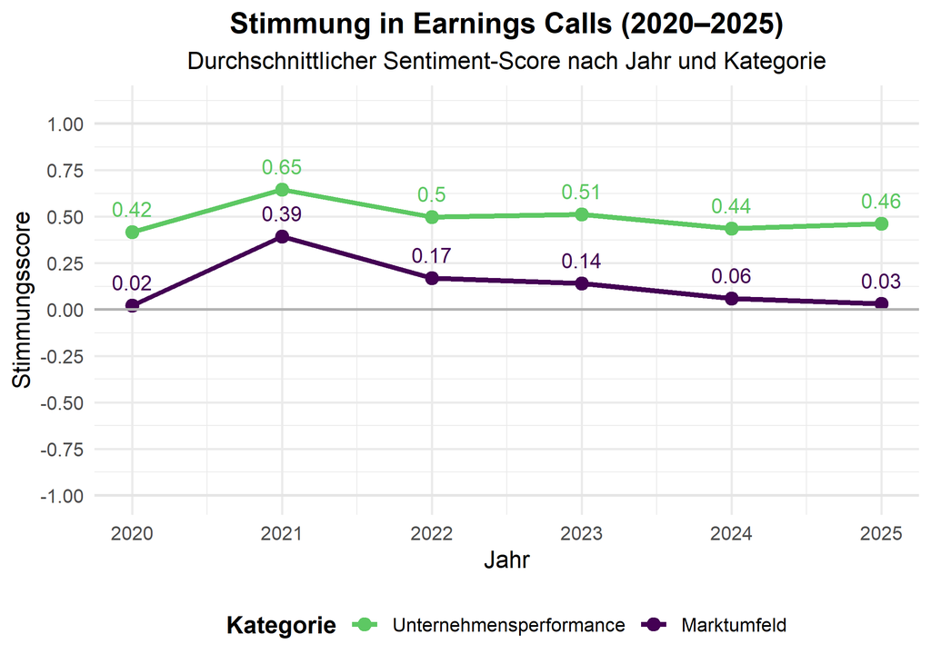

**Entwicklung der Stimmung in Earnings Conference Calls über die Zeit**

**Beschreibung der Grafik**

Die Grafik zeigt die durchschnittlichen Sentiment-Scores (Stimmungs-Bewertungen) in der Q&A-Sektion der Earnings Conference Calls von 2020 bis 2025. Die Stimmung wurde mithilfe eines Large Language Models getrennt nach den Kategorien Unternehmensperformance (grün) und Marktumfeld (violett) erfasst. Für jedes Jahr wurde der Mittelwert aller beobachteten Unternehmen berechnet. Die Punkte sind beschriftet, um die Werte transparent zu machen.

**Interpretation der Stimmung zum Marktumfeld**

Im Gegensatz dazu verläuft die Stimmung zum Marktumfeld deutlich volatiler. Im Jahr 2020 liegt der Wert mit 0.02 nahe an neutral, steigt 2021 jedoch deutlich auf 0.39 an. Danach fällt er fast kontinuierlich: auf 0.17 (2022), 0.14 (2023), 0.06 (2024) und schließlich 0.03 im Jahr 2025. Das zeigt, dass Unternehmen das externe Umfeld zunehmend zurückhaltender und skeptischer einschätzen – besonders ab 2022. Während die eigene Lage meist positiv kommuniziert wird, wird das Marktumfeld mit größerer Unsicherheit gesehen.

**Verbindung zu gesamtwirtschaftlichen Ereignissen**

Diese Muster lassen sich gut mit realen wirtschaftlichen Entwicklungen in Verbindung bringen:

- 2020: Beginn der COVID-19-Pandemie – hohe Unsicherheit, kaum positive Aussagen zum Umfeld
- 2021: Wirtschaftliche Erholung, starke Konjunkturimpulse, daher Aufschwung auch in der Wahrnehmung des Umfelds
- Ab 2022: Ukrainekrieg, Energiekrise, hohe Inflation und Leitzinserhöhungen führen zu wachsender Vorsicht
- 2023–2025: Dauerhafte Unsicherheiten (Geopolitik, Zinsen, globale Spannungen), die Einschätzung des Umfelds bleibt gedrückt

Gleichzeitig bleibt die positive Bewertung der Unternehmensperformance relativ stabil – möglicherweise auch, weil Unternehmen sich stärker auf ihre Stärken konzentrieren oder kommunikativ positiv auftreten wollen.

**Erwartbarkeit der Ergebnisse**

Ja, die dargestellten Entwicklungen sind plausibel und erwartbar. Es ist typisch, dass Unternehmen in öffentlichen Kommunikationsformaten wie Earnings Calls ihre eigene Lage positiver darstellen als das Umfeld. Die stärkere Volatilität und Abwärtstendenz beim Marktumfeld spiegelt wirtschaftliche Realitäten wie Krisen, Rezessionen oder geopolitische Spannungen wider.

# Eventstudie

Um zu evaluieren, ob die Earnings Conference Calls tatsächlich einen Einfluss auf die Aktienkurse der einzelnen Unternehmen hatten können Sie eine sogenannte Eventstudie durchführen, welche Sie bereits in Aufgabe 1 kennen gelernt haben. Bei einer Eventstudie betrachten Sie nur die Zeit (bei uns die Tage) unmittelbar vor oder nach einem Event. In diesem Projekt ist ein Event ein Earnings Conference Call des jeweiligen Unternehmens. Sie sollen in diesem Projekt herausfinden, wie sich über alle Unternehmen hinweg die Earnings Conference Calls auf die Aktienrenditen auswirken.

13. Verbinden Sie den Datensatz über die *Stimmung der Earnings Conference Calls (sentiment.Rds)* zu den einzelnen Unternehmen mit den *abnormalen Renditen* und speichern diesen Datensatz als `gesamtdatensatz` in R ab. Sie können das RIC-Kürzel und Datum für den Join verwenden. Sollte der Earnings Conference Call an keinem Handelstag stattgefunden haben, so joinen Sie bitte mit dem darauffolgenden Handelstag.
- Für die Tage an denen ein Earnings Conference Call stattgefunden hat sollten Sie eine Variable `event` generieren, welche an dem Tag des Calls gleich 0 ist.
- Für die Tage vor dem Earnings Conference Call (Event) sollte die Variable `event` rückwärts zählen (bis zu -5). Für alle Tage nach dem Event sollte die Variable `event` fortgeführt werden (bis +5).
- Erstellen Sie eine Variable `ar_505`, welche die *abnormalen Rendite* von Tag -5 bis +5 **fortlaufend** aufsummiert
- Erstellen Sie eine Variable `car_101`, welche die kumulierte abnormale Rendite im Zeitraum -1 bis +1 um das Event beinhaltet
- Erstellen Sie weiterhin diese sechs neuen Variablen:
  - `negativ_firm` = Wenn die Unternehmensperformance als negativ eingeschätzt wird
  - `neutral_firm` = Wenn die Unternehmensperformance als neutral eingeschätzt wird
  - `positiv_firm` = Wenn die Unternehmensperformance als positiv eingeschätzt wird
  - `negativ_market` = Wenn die Marktperformance als negativ eingeschätzt wird
  - `neutral_market` = Wenn die Marktperformance als neutral eingeschätzt wird
  - `positiv_market` = Wenn die Marktperformance als positiv eingeschätzt wird
- Erstellen Sie Dummy Variablen, die 1 sind für ein bestimmtes Jahr. Bspw. eine Dummyvariable die 2020 heißt und für alle Beobachtungen im Jahr 2020 sollte diese Variable 1 sein, 0 sonst. Tun Sie dies für alle Jahre in ihrem Datensatz

*Hinweis:* Die Funktion cumsum() könnte für diese Aufgabe hilfreich sein

14. Erstellen Sie je ein Liniendiagramm für die von ihnen betrachteten Unternehmen: Eines für die Stimmung bezüglich der Unternehmensperformance und eines bezüglich der Marktperformance.

Sie sollten in ihren Grafiken die kumulierten Renditen im Zeitraum [-5,5] Tage um einen Earnings Conference Call darstellen. - Die Variable “Event” sollte die Tage vor und nach dem Earnings Conference Call enthalten ([-5,5]) und auf der x-Achse dargestellt werden - Die Variable `ar_505` sollte die durchschnittliche kumulierte abnormale Rendite für den jeweiligen Tag auf der y-Achse abtragen (für alle Unternehmen in ihrem Datensatz) - In jeder Grafik sollten Sie eine extra Linie zeichnen für Earnings Conference Calls mit einer positiven/negativen und neutralen Stimmung und deren Einfluss auf den Aktienmarkt

Beschreiben und interpretieren Sie ihre Grafik. Gehen Sie hierbei insbesondere darauf ein, welche Erwartungen Sie auf der Basis ihrer Lektüre aus Aufgabe 1 hatten und in wie weit diese Erwartungen sich erfüllt haben.

*Hinweis:* In diesen Grafiken stellen Sie nicht jedes Event (d.h. die Auswirkungen eines jeden Earnings Conference Calls) einzeln dar, sondern gesamt für alle Earnings Conference Calls.

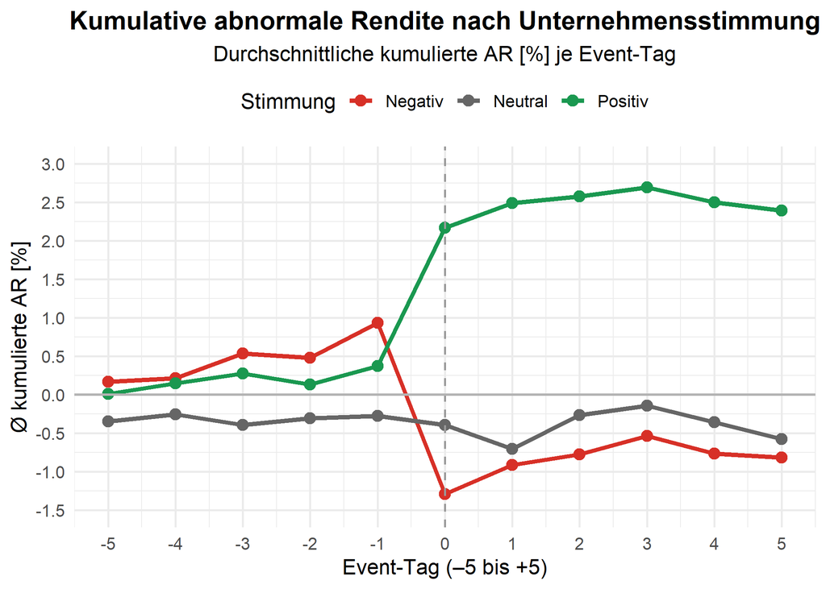

**Wirkung von Unternehmensstimmung auf kumulierte abnormale Renditen**

**Beschreibung der Grafik**

Die Grafik zeigt die durchschnittliche kumulierte abnormale Rendite (AR) im Zeitraum von fünf Handelstagen vor bis fünf Handelstagen nach einem Earnings Conference Call (Event-Zeitfenster = [–5, +5]). Die kumulierte AR misst, wie stark sich der Aktienkurs im Vergleich zur erwarteten Entwicklung verändert hat – also, ob sich Investorenreaktionen anhand der Unternehmenskommunikation nachweisen lassen.

Die Daten sind in drei Gruppen unterteilt, basierend auf der vom Management vermittelten Stimmung in der Q&A-Sektion:

- Positiv (grün)
- Neutral (grau)
- Negativ (rot)

Die x-Achse zeigt die Event-Tage, wobei der Tag 0 dem Call-Datum entspricht. Die y-Achse bildet die durchschnittliche kumulierte abnormale Rendite in Prozent ab. Dadurch wird ersichtlich, wie sich der Aktienkurs im Umfeld des Calls in Abhängigkeit von der wahrgenommenen Stimmung entwickelt.

**Interpretation der Ergebnisse**

*Positive Stimmung (grün):*

Bei Calls mit positivem Sentiment ist ab Event-Tag 0 ein deutlicher Anstieg der kumulierten AR zu beobachten. Bereits am Folgetag (Tag +1) liegt die kumulierte Rendite über +2% und steigt bis Tag +3 auf rund +2,8%. Das deutet auf eine sehr positive Marktreaktion hin – Investoren scheinen optimistische Aussagen des Managements unmittelbar einzuordnen und mit steigenden Kursen zu honorieren.

*Neutrale Stimmung (grau):*

Die neutrale Gruppe zeigt über das gesamte Zeitfenster hinweg einen nahezu flachen Verlauf. Es sind weder signifikante Anstiege noch Rückgänge erkennbar. Das spricht dafür, dass der Markt auf neutrale oder erwartbare Kommunikation weitgehend indifferent reagiert.

**Einordnung im Kontext der Theorie (vgl. Aufgabe 1)**

Wie bereits in Aufgabe 1 erläutert, gehen Eventstudien davon aus, dass unerwartete Informationen Kursreaktionen auslösen – und genau das zeigt sich in der Grafik:

- Positive Überraschungen führen zu systematisch steigenden Renditen.
- Negative Aussagen rufen messbare Verluste hervor.
- Neutrale Inhalte bewirken kaum Bewegung.

**Fazit**

Die Grafik zeigt deutlich, dass die Stimmung in Earnings Conference Calls einen spürbaren Einfluss auf die Aktienkurse hat – insbesondere in den Tagen direkt nach dem Call. Die Ergebnisse untermauern die Grundannahmen der Event-Study-Methodik und zeigen, wie stark qualitative Informationen vom Kapitalmarkt aufgenommen werden. Besonders hervorzuheben ist der unmittelbare und über mehrere Tage anhaltende Effekt negativer Kommunikation – ein klares Signal für die Bedeutung einer strategischen und transparenten Unternehmenskommunikation im Umgang mit Investoren.

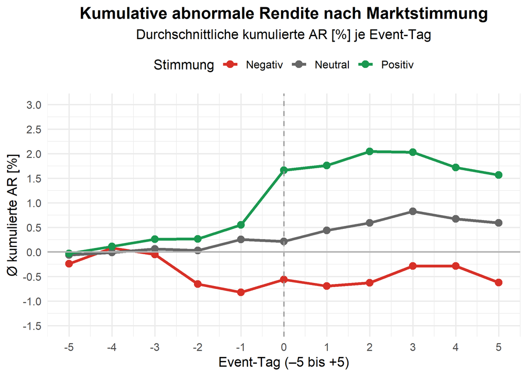

**Wirkung der Marktstimmung auf kumulierte abnormale Renditen**

**Beschreibung der Grafik**

Die Grafik zeigt die durchschnittliche kumulierte abnormale Rendite (AR) im Zeitraum von fünf Handelstagen vor bis fünf Handelstagen nach dem Earnings Conference Call (Event-Fenster = [–5, +5]). Die AR misst die Abweichung der Aktienrendite von der erwarteten Entwicklung, z.B. im Vergleich zum Markt.

Die Daten wurden auf Basis der vom Management kommunizierten Einschätzung des externen Marktumfelds in der Q&A-Sektion in drei Gruppen unterteilt:

- Positiv (grün)
- Neutral (grau)
- Negativ (rot)

Die x-Achse zeigt die Event-Tage (0 = Call-Tag), die y-Achse die durchschnittlich kumulierte AR in Prozent.

**Interpretation der Ergebnisse**

*Positive Marktstimmung:*

Die grüne Linie zeigt ab Event-Tag 0 einen klaren Anstieg. Die kumulierte AR steigt bis Tag +3 auf über +2% und bleibt anschließend auf hohem Niveau. Das deutet darauf hin, dass Anleger positive Aussagen zum Marktumfeld – etwa zu makroökonomischen Trends oder Branchenaussichten – als wertvoll einschätzen und mit Kursgewinnen reagieren.

*Neutrale Marktstimmung:*

Die graue Linie verläuft relativ flach mit einem leichten Anstieg nach dem Call. Die kumulierte AR erreicht bis Tag +3 rund +1%, bleibt aber insgesamt stabil. Das legt nahe, dass neutrale Aussagen zum Marktumfeld vom Markt kaum interpretiert werden – vermutlich, weil sie keine neue Information enthalten.

**Einordnung im Kontext der Theorie (vgl. Aufgabe 1)**

Nach dem Event-Study-Konzept führen neue und unerwartete Informationen zu Kursreaktionen. Aussagen über das Marktumfeld sind zwar weniger konkret als zur eigenen Unternehmenslage, doch die Grafik zeigt, dass sie dennoch Wirkung entfalten können – besonders wenn sie positiv oder negativ konnotiert sind.

Im Vergleich zur Wirkung der Unternehmensstimmung (siehe vorherige Grafik) fällt der Effekt etwas schwächer aus, ist aber klar erkennbar und plausibel. Anleger betrachten Unternehmen nicht isoliert, sondern im Kontext des Marktes, in dem sie agieren.

**Verbindung beider Ergebnisse**

Die beiden Analysen ergeben ein konsistentes Bild:

- Die Stimmung zur eigenen Unternehmenslage beeinflusst die Renditen am stärksten.
- Die Markteinschätzung wirkt ebenfalls – aber etwas schwächer.

Beide Effekte sind in Richtung und Timing logisch und empirisch nachvollziehbar. Das spricht sowohl für die Qualität der Sentiment-Messung durch das LLM als auch für die Aussagekraft der Event-Study-Methode in diesem Kontext.

# Regressionen

Sie haben bisher den Einfluss der Earnings Conference Calls auf die Aktienrendite der größten europäischen Unternehmen im Technologie-Sektor visuell betrachtet. Im letzten Abschnitt dieser Projektarbeit analysieren Sie ihre Daten mittels linearer Regressionen.

15. In dieser Aufgabe sollten Sie zwei Regressionen erstellen:

Regressieren Sie die kumulierten abnormalen Renditen um das Event `car_101` auf die Dummyvariablen

- `negativ_firm` und `negativ_market` in der ersten Regression und
- `positiv_firm` und `positiv_market` in der zweiten Regression.

Diese Dummyvariablen geben die Stimmung in den Earnings-Conference Calls wieder.

Beschreibung und interpretieren Sie ihre Regressionsergebnisse und gehen Sie dabei auch auf folgende Fragen ein:

- Was ist die Vergleichsgruppe in den beiden Regressionen?
- Was sind die Voraussetzungen für eine kausale Interpretation der Koeffizienten. Sind diese ihrer Meinung nach gegeben?

Regression der kumulierten abnormalen Rendite (car_101) nach Stimmung im Earnings Call

|  | Regression (negativ) | Regression (positiv) |
| --- | --- | --- |
| Konstante | 1.382** | -0.754 |
|  | (0.525) | (0.677) |
| Negative Stimmung (Unternehmen) | -2.690* |  |
|  | (1.155) |  |
| Negative Stimmung (Markt) | -0.554 |  |
|  | (1.738) |  |
| Positive Stimmung (Unternehmen) |  | 3.259** |
|  |  | (1.003) |
| Positive Stimmung (Markt) |  | -0.242 |
|  |  | (1.025) |
| Num.Obs. | 368 | 368 |
| R2 | 0.015 | 0.032 |
| R2 Adj. | 0.010 | 0.027 |
| AIC | 2650.2 | 2643.9 |
| BIC | 2665.9 | 2659.6 |
| Log.Lik. | -1321.118 | -1317.962 |
| F | 2.849 | 6.055 |
| RMSE | 8.77 | 8.69 |

+ p < 0.1, * p < 0.05, ** p < 0.01, *** p < 0.001

**Ziel der Analyse**

Um den Einfluss der in Earnings Calls geäußerten Stimmung auf kurzfristige Kursreaktionen zu untersuchen, wurden zwei lineare Regressionen durchgeführt. Als Zielvariable dient die kumulierte abnormale Rendite im Zeitraum von –1 bis +1 Tagen um den Event-Tag (car_101). Die erklärenden Variablen sind binäre Indikatoren für positive bzw. negative Stimmung, jeweils getrennt nach Unternehmens- und Markteinschätzung.

**Beschreibung der Regressionsmodelle**

In Modell 1 (linke Spalte) wurde untersucht, wie sich eine negative Stimmung des Managements auf die abnormale Rendite auswirkt. Die unabhängigen Variablen sind:

- negativ_firm: negativ bewertete Aussagen zur eigenen Unternehmenslage,
- negativ_market: negativ bewertete Aussagen zum Marktumfeld.

In Modell 2 (rechte Spalte) wurde entsprechend die positive Stimmung analysiert:

- positiv_firm: positiv bewertete Aussagen zum Unternehmen,
- positiv_market: positiv bewertete Aussagen zum Markt.

**Interpretation der Ergebnisse**

Die Ergebnisse liefern ein klares Bild:

Negative Unternehmensstimmung hat einen signifikanten negativen Effekt:

- Ein negativer Ton in Bezug auf das eigene Unternehmen senkt die kumulierte Rendite um durchschnittlich –2.69 Prozentpunkte (p < 0.05).

Positive Unternehmensstimmung zeigt einen signifikanten positiven Effekt:

- Ein optimistischer Unternehmensausblick führt zu einem Anstieg der Rendite um +3.26 Prozentpunkte (p < 0.01).

Marktstimmung, ob negativ oder positiv, hat keinen signifikanten Effekt auf die Rendite. Beide Koeffizienten sind statistisch unbedeutend und relativ klein (–0.55 bzw. –0.24).

Diese Ergebnisse deuten darauf hin, dass Investoren vor allem auf Aussagen zur eigenen Unternehmenssituation reagieren – weniger jedoch auf allgemeine Aussagen zum Marktumfeld.

**Statistische Güte und Modellvergleich**

Die erklärten Varianzen (R²) sind mit 0.015 bzw. 0.032 relativ gering, was bei Eventstudien mit hoher Datenstreuung typisch ist. Dennoch zeigt sich, dass das Modell mit positiver Stimmung etwas besser passt (höheres R², besserer F-Wert).

**Kausale Interpretation – Grenzen der Aussagekraft**

Für eine kausale Deutung müssten folgende Voraussetzungen erfüllt sein:

- Keine unbeobachteten Drittvariablen, die sowohl Sentiment als auch Rendite beeinflussen.
- Exogenität der Stimmung: Die Stimmung darf nicht durch erwartete Kursreaktionen beeinflusst sein.
- Keine systematische Selektion: Die beobachteten Calls müssen repräsentativ sein und dürfen nicht von unternehmensseitiger Vorauswahl verzerrt werden.

Da es sich um beobachtete, nicht-experimentelle Daten handelt, sind diese Bedingungen nur eingeschränkt erfüllt. Die Ergebnisse sind daher deskriptiv zu interpretieren, nicht als kausale Wirkzusammenhänge.

**Fazit**

Die Regressionsanalyse bestätigt, dass Aussagen zur Unternehmenslage in Earnings Calls einen signifikanten Einfluss auf die kurzfristige Kursentwicklung haben. Positive Aussagen führen zu klaren Gewinnen, negative zu Verlusten. Aussagen zur allgemeinen Marktlage bleiben dagegen weitgehend ohne Wirkung. Die Ergebnisse verdeutlichen, wie stark qualitative Inhalte – insbesondere zur eigenen Geschäftsentwicklung – vom Kapitalmarkt aufgenommen und verarbeitet werden.

16. In ihrer deskriptiven Analyse haben Sie bereits gesehen, dass die Unternehmen, die Sie in diesem Projekt betrachten, alle unterschiedlich groß sind. Weiterhin haben Sie gesehen, dass es ein unterschiedliches Stimmungsbild in den Calls über die einzelnen Jahre hinweg gibt. Dafür möchten Sie in ihren Regressionen nun kontrollieren.
    1. Regressieren Sie die `car_101` auf die Variablen *negativ_firm* und *negativ_market* und kontrollieren Sie auf die Größe des jeweiligen Unternehmens, indem Sie die Variable *Total_Assets* in ihre Regression aufnehmen
    2. Fügen Sie in einer zweiten Analyse zusätzlich zu den Variablen aus der 1. Regression auch noch Dummyvariablen für die Jahre in dem das Event stattgefunden hat ihrer Regression hinzu.
    3. Führen Sie die Regressionen aus 1. und 2. auch für die Variablen *positiv_firm* und *positiv_market* anstatt *negativ_firm* und *negativ_market* durch, sodass Sie am Ende 4 Regressionen haben

Beschreiben und interpretieren Sie ihre Ergebnisse im Hinblick auf die Größe der Koeffizienten und deren Signifikanz. Gehen Sie insbesondere auf folgende Fragen ein:

- Warum sollte ihre Regression nicht fünf Dummyvariablen, je eine für jedes Jahr, sondern nur vier beinhalten?
- Verändert sich durch die Dummyvariablen der Koeffizient von *negativ_firm* und *negativ_market* bzw. *positiv_firm* und *positiv_market*?
- Hätten Sie eine Veränderung des Koeffizienten von *negativ_firm*, *negativ_market*, *positiv_firm* oder *positiv_market* erwartet? Begründen Sie ihre Antwort mit ihren deskriptiven Analysen.

Regression der kumulierten abnormalen Rendite (car_101) mit Kontrolle für Unternehmensgröße und Jahresdummies

|  | Negativ-Stimmung | Negativ-Stimmung und Jahr | Positiv-Stimmung | Positiv-Stimmung und Jahr |
| --- | --- | --- | --- | --- |
| Konstante | 3.342 | 4.551 | 1.206 | 2.574 |
|  | (2.454) | (3.873) | (2.506) | (3.847) |
| Negative Stimmung (Unternehmen) | -2.599* | -2.589* |  |  |
|  | (1.154) | (1.166) |  |  |
| Negative Stimmung (Markt) | -0.662 | -0.652 |  |  |
|  | (1.764) | (1.770) |  |  |
| Gesamtvermögen | 0.000 | 0.000 | 0.000 | 0.000 |
|  | (0.000) | (0.000) | (0.000) | (0.000) |
| Jahr 2021 |  | -0.496 |  | -0.841 |
|  |  | (1.436) |  | (1.449) |
| Jahr 2022 |  | 1.668 |  | 1.479 |
|  |  | (1.817) |  | (1.810) |
| Jahr 2023 |  | 1.631 |  | 1.540 |
|  |  | (2.331) |  | (2.314) |
| Jahr 2024 |  | -1.312 |  | -1.363 |
|  |  | (2.389) |  | (2.371) |
| Positive Stimmung (Unternehmen) |  |  | 3.152** | 3.168** |
|  |  |  | (1.006) | (1.013) |
| Positive Stimmung (Markt) |  |  | -0.342 | -0.278 |
|  |  |  | (1.032) | (1.043) |
| Num.Obs. | 364 | 364 | 364 | 364 |
| R2 | 0.017 | 0.032 | 0.032 | 0.047 |
| R2 Adj. | 0.009 | 0.013 | 0.024 | 0.028 |
| AIC | 2620.0 | 2622.3 | 2614.5 | 2616.7 |
| BIC | 2639.4 | 2657.4 | 2633.9 | 2651.8 |
| Log.Lik. | -1304.978 | -1302.157 | -1302.226 | -1299.343 |
| F | 2.070 |  | 3.929 |  |
| RMSE | 8.72 | 8.66 | 8.66 | 8.59 |

+ p < 0.1, * p < 0.05, ** p < 0.01, *** p < 0.001

**Zielsetzung und Regressionsdesign**

Um die Robustheit der Haupteffekte zu überprüfen, wurden vier lineare Regressionsmodelle geschätzt, in denen die kumulierte abnormale Rendite (car_101) um den Earnings Conference Call auf die Stimmungslage regressiert wurde. Dabei wurde systematisch kontrolliert für:

- die Größe des Unternehmens (Total_Assets), da größere Firmen potenziell anders auf Informationen reagieren oder von Investoren anders wahrgenommen werden,
- sowie für zeitliche Effekte durch Jahresdummies, um konjunkturelle Schwankungen oder makroökonomische Sondereffekte zu berücksichtigen.

Diese Struktur ermöglicht es, den Einfluss der Stimmungsvariablen isolierter zu betrachten und potenzielle Confounder auszuschließen.

**Ergebnisse im Überblick**

*Negatives Firmensentiment:*

Modell 1 (ohne Jahresdummies): –2.599, p < 0.05

Modell 2 (mit Jahresdummies): –2.589, p < 0.05

In beiden Modellen zeigt sich ein signifikanter negativer Effekt: Wenn das Management in der Q&A-Sektion negativ über das eigene Unternehmen spricht, fällt die Rendite im Event-Zeitraum um rund 2.6 Prozentpunkte. Die nahezu identische Höhe des Effekts über beide Modelle hinweg unterstreicht die Robustheit dieses Zusammenhangs.

*Positives Firmensentiment:*

Modell 3 (ohne Jahresdummies): +3.152, p < 0.01

Modell 4 (mit Jahresdummies): +3.168, p < 0.01

Positive Einschätzungen zum Unternehmen führen zu einem signifikanten Kursanstieg von über drei Prozentpunkten. Auch hier bleibt der Effekt trotz zusätzlicher Kontrollvariablen stabil, was auf einen direkten, verlässlichen Zusammenhang zwischen positiver Stimmung und Kursreaktion hinweist.

**Marktsentiment**

Das Marktsentiment – also Aussagen über das wirtschaftliche Umfeld – zeigt keinen signifikanten Einfluss auf die kurzfristige Kursentwicklung. Das spricht dafür, dass Investoren den firmenspezifischen Informationen im Call deutlich mehr Gewicht beimessen als allgemeinen Branchenaussagen.

**Rolle der Jahresdummies**

In den Modellen 2 und 4 wurden Jahresdummies für 2021 bis 2024 integriert (2020 ist Referenzjahr). Die geschätzten Effekte zeigen zwar Richtungstendenzen – etwa ein negativer Effekt für 2024 (–1.312 / –1.363) und ein positiver für 2022 – doch keiner der Jahreskoeffizienten ist statistisch signifikant.

Dies legt nahe, dass es keine systematischen Unterschiede im Kursreaktionsmuster zwischen den Jahren gibt, sobald die Stimmung des Calls berücksichtigt wird. Mögliche konjunkturelle Effekte scheinen also entweder schwach oder durch das Firmensentiment überlagert zu werden.

**Warum vier und nicht fünf Jahresdummies?**

Aus statistischer Sicht dürfen in der Regression mit einem festen Interzept nie alle Kategorien einer kategorialen Variable als Dummyvariablen aufgenommen werden. Dies würde zu perfekter Multikollinearität führen („Dummy Variable Trap“), wodurch die Regressionsgleichung nicht mehr eindeutig lösbar wäre. Stattdessen wird eine Referenzkategorie ausgelassen – hier das Jahr 2020 – auf die sich alle anderen Jahreskoeffizienten beziehen. Der Interzept der Regression ist also die geschätzte Rendite für einen neutralen Call im Jahr 2020.

**Verändert sich der Effekt durch die Kontrollen?**

Bemerkenswert ist, dass sich weder die Richtung noch die Stärke der Haupteffekte (positiv_firm, negativ_firm) durch die Einbeziehung der Kontrollvariablen nennenswert verändern. Die geschätzten Werte variieren nur um wenige Hundertstel-Prozentpunkte. Das spricht für eine hohe interne Validität der Modelle und legt nahe, dass die beobachteten Effekte nicht durch systematische Unterschiede zwischen großen und kleinen Firmen oder durch spezifische Jahresereignisse verzerrt sind.

**Hätte man eine Veränderung erwartet?**

Auf Basis der deskriptiven Analyse – insbesondere aus Aufgabe 12 – war nicht mit substanziellen Verzerrungen zu rechnen. Die durchschnittlichen Stimmungswerte und Renditen wiesen nur moderate Schwankungen über die Jahre auf. Dennoch war es methodisch wichtig, Kontrollvariablen einzubeziehen, um auszuschließen, dass etwa große Unternehmen systematisch positiver kommunizieren oder einzelne Jahre besonders auffällig sind.

**Fazit**

Die erweiterten Regressionsmodelle bestätigen den zentralen Befund des Projekts:

- Die Stimmung zur Unternehmensperformance im Earnings Call hat einen signifikanten und robusten Einfluss auf kurzfristige Kursreaktionen.
- Dieser Effekt bleibt auch dann bestehen, wenn Unterschiede in Unternehmensgröße und Makroumfeld berücksichtigt werden. Aussagen zum allgemeinen Marktumfeld hingegen haben keine systematische Wirkung.
- Die Stabilität der Ergebnisse über verschiedene Modellspezifikationen hinweg unterstreicht ihre ökonomische Relevanz und stärkt die Aussagekraft deiner Analyse.
17. Zum Abschluss sollten Sie dazu Stellung beziehen, in wie weit die Erkenntnisse aus diesem Projekt für eine Handelsstrategie genutzt werden könnten. Konkret sollten Sie erläutern ob es sinnvoll ist eine Unternehmensaktie bei einem negativem Sentiment im Earnings Conference Call automatisiert zu verkaufen.

Beziehen Sie sich in ihrer Argumentation insbesondere auf:

- Zeitliche Aspekte (Wann reagiert der Markt vs. wann liegt das Sentiment vor?)
- Methodische Limitationen Ihrer Event Study
- Unsicherheiten bei der LLM-Sentiment-Analyse

Begründen Sie jeden Kritikpunkt konkret mit Bezug auf Ihre Projektarbeit und schließen Sie mit einer realistischen Einschätzung ab: Wofür könnten Ihre Ergebnisse trotz dieser Limitationen in der Praxis dennoch wertvoll sein?

**Bewertung der praktischen Nutzbarkeit für Handelsstrategien**

Die Ergebnisse dieses Projekts zeigen, dass das Sentiment in Earnings Conference Calls – insbesondere zur Unternehmensperformance – einen signifikanten Einfluss auf kurzfristige, kumulierte abnormale Renditen hat. Negatives Firmensentiment ist mit deutlichen Kursverlusten assoziiert, während positives Sentiment überdurchschnittliche Renditen erwarten lässt. Daraus könnte man ableiten, dass ein automatisierter Verkauf bei negativem Sentiment grundsätzlich sinnvoll wäre. In der praktischen Umsetzung ist dies jedoch mit mehreren Einschränkungen verbunden.

**Zeitliche Aspekte: Reagiert der Markt schneller als der Algorithmus?**

Ein zentrales Problem ist das Timing. In der Realität reagieren Märkte oft bereits während des Calls, spätestens aber unmittelbar danach. Die Analyse in diesem Projekt basiert hingegen auf Sentiment-Scores, die mithilfe eines LLM (Google Gemini) aus vollständigen, manuell aufbereiteten Transkripten erzeugt wurden – also zeitlich verzögert, teils erst Tage nach dem Event. Ein automatisiertes Handelssystem, das auf diesen Daten basiert, käme daher zu spät, um vom initialen Kurseffekt zu profitieren.

Institutionelle Marktteilnehmer setzen zum Teil auf Live-Speech-to-Text-Systeme mit integrierter Echtzeit-Sentimentanalyse – in unserem Projekt war ein solcher Ansatz jedoch nicht möglich.

**Methodische Limitationen der Event Study**

Auch methodisch ist die Aussagekraft der Event Study eingeschränkt. Zwar wurde das Event-Fenster bewusst eng gewählt ([–1, +1], car_101), um unmittelbare Kursreaktionen abzubilden. Doch auch in diesem Zeitraum können konkurrierende Ereignisse auftreten – etwa makroökonomische Schocks, politische Nachrichten oder firmenspezifische Ankündigungen – die nicht vollständig kontrolliert wurden.

Zudem basiert unsere Analyse auf historischen Daten. Selbst wenn die Befunde in der Vergangenheit konsistent waren, ist nicht garantiert, dass sie sich auch in zukünftigen Marktphasen replizieren lassen – etwa bei geänderter Regulierung, Sentiment-Dynamik oder Marktstruktur.

**Unsicherheiten bei der LLM-Sentiment-Analyse**

Die Klassifikation des Sentiments durch ein Large Language Model ist zwar innovativ, aber mit gewissen Unsicherheiten verbunden:

- Der eingesetzte Zero-Shot-Prompt wurde nicht formal validiert.
- Feinere Nuancen der Sprache – etwa Ironie, Kontextwechsel oder branchenspezifische Fachbegriffe – können leicht fehlinterpretiert werden.
- Die Sentiment-Kategorien sind diskret (positiv / neutral / negativ), während die tatsächliche Stimmung kontinuierlich verläuft.
- Fehlklassifikationen können in der Praxis zu unnötigen Transaktionen oder verpassten Chancen führen – insbesondere wenn das Modell systematisch in eine Richtung verzerrt ist.

**Fazit: Kein direkter Einsatz für automatisierte Verkäufe – aber wertvolle Analysebasis**

Ein vollautomatisierter Verkauf auf Basis negativ bewerteter Earnings Calls wäre in der Praxis kaum umsetzbar. Der Markt ist meist schneller, die zugrunde liegende Methodik hat Limitierungen, und die Sentiment-Klassifikation ist nicht fehlerfrei. Auch Transaktionskosten, Liquiditätsrisiken und falsche Signale wurden in der Analyse nicht berücksichtigt.

*Trotzdem liefert die Analyse wertvolle Einsichten für:*

- Analysten und Investoren, um Kursreaktionen besser zu verstehen und zu erklären,
- institutionelle Anleger, die systematisch Kommunikationsmuster überwachen,
- und Investor-Relations-Abteilungen, die lernen können, wie ihre Aussagen vom Markt interpretiert werden.

Die Event-Study ist damit keine konkrete Handelsstrategie, aber eine verlässliche Grundlage für qualitative Marktanalyse und strategische Kommunikation.

# Zusatzaufgabe

In Aufgabe 6 berechnen Sie die *abnormalen Renditen* der einzelnen von ihnen betrachteten Unternehmen. Nun könnte es allerdings sein, dass es nicht ausreicht den Marktindex einfach von der Aktienrendite abzuziehen um für die erwartete Performance der Aktie zu kontrollieren. Potentiell wäre es besser für die durchschnittliche Performance der Aktie zu kontrollieren in der keine Events stattfinden.

Sie können eine solche durchschnittliche Performance schätzen. Dazu sollten Sie eine Schätzperiode *vor* dem Event definieren. Diese Periode sollen Sie auf 120 bis 10 Handelstage vor dem Event festlegen. Die durchschnittliche Rendite der Einzelaktie sollten Sie in dieser Periode auf die Marktrendite regressieren. Dieses Modell wird `Risk-adjusted returns model` in Huntington-Klein (2021) genannt:

$$\begin{equation}
\hat{Rendite}_{i,t} = \alpha + \beta Rendite_{m,t}
\end{equation}$$

Anschließend nutzen Sie die vorhergesagten Werte und ziehen diese in der Eventphase von der Rendite der Einzelaktie ab.

18. Erstellen Sie die kumulierten abnormalen Renditen im Zeitraum -5 bis +5 mit Hilfe ihres Risk-adjusted returns model neu (und nennen diese `mar_505`). Erstellen Sie die kumulierten abnormalen Renditen im Zeitraum -1 bis +1 um das Event mit Hilfe ihres Risk-adjusted returns model neu (und nennen die Variable `cmar_101`) und vergleichen die Werte in einer geeigneten Grafik mit den Ergebnissen aus dem market-adjusted returns model (`car_101`).
- Gibt es hier große Unterschiede?
- Warum gibt es diese Unterschiede, oder warum sehen Sie nur geringe Unterschiede?

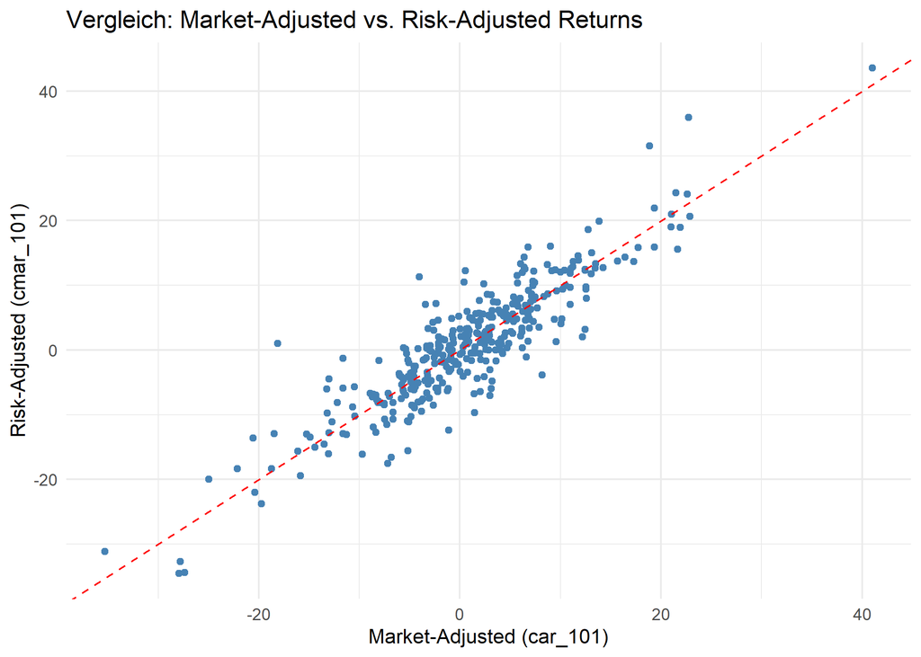

**Methodischer Hintergrund**

In der bisherigen Analyse wurden die abnormalen Renditen (car_101) im Rahmen eines simplen Market-Adjusted Models berechnet, das lediglich die Rendite des Marktindex von der tatsächlichen Rendite der Aktie abzieht. Dieses Verfahren unterstellt, dass alle Aktien im Durchschnitt die Marktentwicklung widerspiegeln – unabhängig von ihrer individuellen Risikostruktur.

Das Risk-Adjusted Returns Model nach Huntington-Klein (2021) erlaubt eine differenziertere Schätzung: Für jede Aktie wird zunächst in einer Schätzperiode (hier: -120 bis -10 Handelstage vor dem Event) eine Regressionsbeziehung zur Marktrendite geschätzt. Daraus ergeben sich aktienspezifische α- und β-Werte, mit denen sich die erwartete Rendite der Aktie in der Eventperiode prognostizieren lässt. Die Differenz zur tatsächlichen Rendite ergibt dann die risk-adjusted abnormal return. Die kumulierten Werte im Zeitfenster [-5, +5] bzw. [-1, +1] wurden in den Variablen mar_505 und cmar_101 gespeichert.

**Grafischer Vergleich und Interpretation**

Die Grafik zeigt den Vergleich zwischen car_101 (Market-Adjusted) und cmar_101 (Risk-Adjusted) in Form eines Streudiagramms:

**Gibt es große Unterschiede zwischen den Modellen?**

Nein, insgesamt sind die Unterschiede gering. Beide Methoden liefern in der Regel ähnliche Schätzwerte für die kumulierten abnormalen Renditen.

**Warum gibt es diese (fast nicht vorhandenen) Unterschiede?**

Die geringe Differenz lässt sich dadurch erklären, dass viele der betrachteten Unternehmen stark mit dem Markt korrelieren, sodass der einfache Abzug der Marktrendite (car_101) bereits eine gute Näherung liefert. Außerdem ist die Eventperiode [-1, +1] relativ kurz, wodurch das individuelle Beta der Aktie weniger stark ins Gewicht fällt. In einzelnen Fällen mit sehr hoher oder niedriger Marktsensitivität können jedoch deutlichere Abweichungen auftreten (siehe Ausreißer in der Grafik).

**Fazit**

Die Anwendung des risk-adjusted Modells führt zu keinem grundsätzlich anderen Bild als das einfache market-adjusted Modell, verleiht der Analyse jedoch methodisch mehr Präzision. Für eine robuste Schätzung in sensiblen Eventstudien – insbesondere bei stark unterschiedlichen Betas – ist dieses Modell daher zu bevorzugen. In der vorliegenden Analyse lässt sich jedoch feststellen, dass die zentralen Ergebnisse weitgehend konsistent bleiben.

19. Erstellen Sie die Grafik von Aufgabe 12 neu.

Beschreiben und interpretieren Sie ihre Grafik. Gehen Sie auch auf folgende Fragen ein:

- Könnte es zu Problemen führen, wenn in der Schätzperiode vor dem Event ein weiterer Earnings-Conference Call enthalten ist?
  - Warum könnte dies ein Problem sein, oder warum nicht?

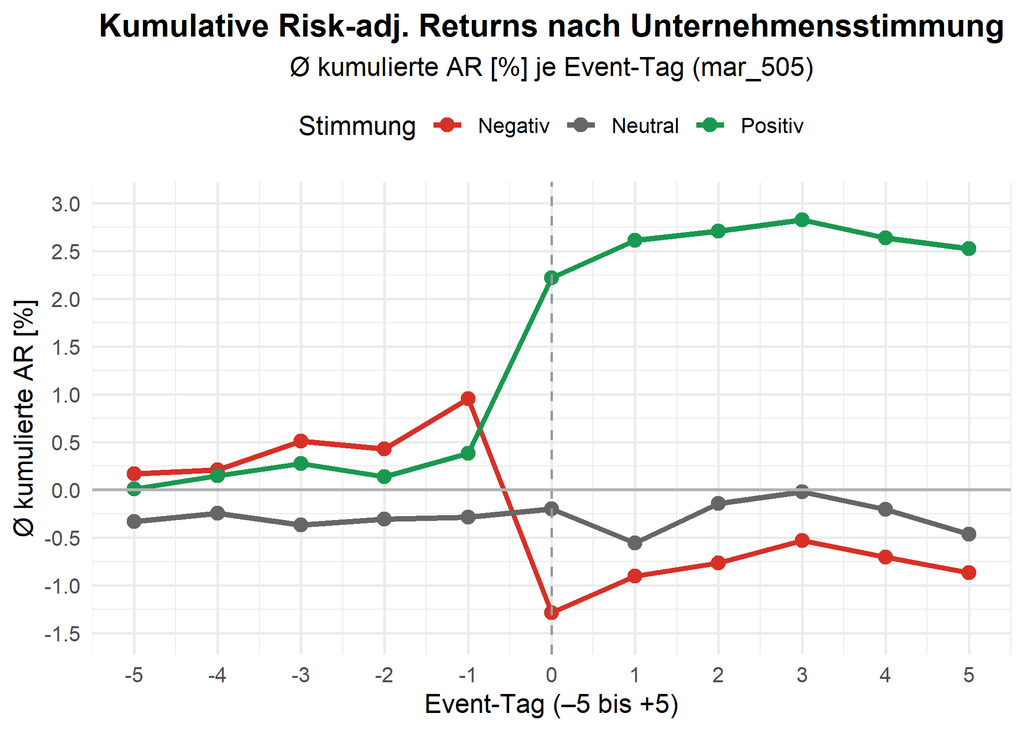

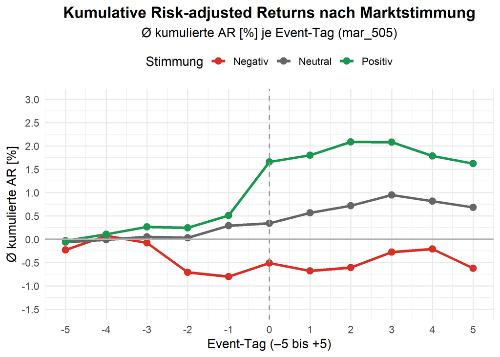

**Hintergrund**

In Aufgabe 14 wurde bereits untersucht, wie sich das Stimmungsbild der Earnings Calls auf die kumulierten abnormalen Renditen (CARs) auswirkt. Die Berechnung erfolgte dort mithilfe des einfachen Market-adjusted returns model. In Aufgabe 18 wurde dieses Verfahren nun durch das Risk-adjusted returns model erweitert, das eine regressionsbasierte Schätzung der erwarteten Rendite in einer Schätzperiode vor dem Event nutzt. Ziel von Aufgabe 19 ist es, die neuen Resultate aus dem risk-adjustierten Modell mit den bisherigen Ergebnissen aus Aufgabe 14 zu vergleichen, diese zu interpretieren und potenzielle methodische Schwächen zu reflektieren.

**Beschreibung der neuen Grafiken**

Die beiden Liniengrafiken zeigen die durchschnittlichen kumulierten abnormalen Renditen im Event-Zeitfenster von –5 bis +5 Tagen, diesmal berechnet mit dem Risk-adjusted model (mar_505), getrennt nach Unternehmensstimmung und Marktstimmung.

*Fazit:*

Der Vergleich zeigt, dass die zentralen Erkenntnisse nicht vom gewählten Modell abhängig sind, sondern sich stabil reproduzieren lassen. Das erhöht die Aussagekraft und methodische Glaubwürdigkeit der Analyse.

**Reflexion: Können weitere Calls in der Schätzperiode das Modell verzerren?**

Ein kritischer Punkt betrifft die Konstruktion des Risk-adjusted Models. Dieses basiert auf einer Regressionsschätzung der erwarteten Rendite in einer Schätzperiode von 120 bis 10 Tagen vor dem Event. Problematisch wird dies, wenn sich in dieser Periode bereits ein anderer Earnings Call desselben Unternehmens befindet.

**Warum ist das ein Problem?**

Earnings Calls lösen oft selbst signifikante Kursbewegungen aus. Diese Kursreaktionen fließen dann fälschlich in die “normale” Erwartung der Rendite ein. Das führt zu einer verzerrten Schätzung der Parameter α und β im Modell – was wiederum die abnormalen Renditen verfälscht. In der Folge würde ein Teil des Events selbst als „normal“ klassifiziert, wodurch der eigentliche Event-Effekt unterschätzt wird.

*Lösungsperspektive:*

In zukünftigen Analysen sollte überprüft werden, ob frühere Events in der Schätzperiode liegen. Solche Beobachtungen könnten dann ausgeschlossen oder durch ein robustes Panelmodell mit fixen Effekten ersetzt werden.

**Zusammenfassung**

Damit bestätigt sich erneut: Die mit dem LLM analysierten Stimmungskategorien besitzen eine relevante Informationsfunktion für Investoren – unabhängig vom verwendeten Modellansatz.

20. Lesen Sie das Kapitel [“Fixed Effects” in Huntington-Klein (2021)](https://theeffectbook.net/ch-FixedEffects.html#how-does-it-work), speziell Kapitel 16.1
21. Regressieren Sie die `cmar_101` auf die Variablen *negativ_firm* und *negativ_market* und kontrollieren Sie auf die Größe des jeweiligen Unternehmens, indem Sie die Variable *Total_Assets* in ihre Regression aufnehmen. Kontrollieren Sie weiterhin auf das Jahr in dem das Event stattgefunden hat. Fügen Sie weiterhin der Regression Firmen-Fixe Effekte hinzu.

Beschreiben und interpretieren Sie ihre Ergebnisse.

Gehen Sie zusätzlich auf die folgenden Frage ein:

- Was sind Firmen-Fixe Effekte und warum könnten diese für ihre Regression sinnvoll sein?

*Hinweis:* Mit dem [Paket `fixest`](https://cran.r-project.org/web/packages/fixest/vignettes/fixest_walkthrough.html) und der Funktion feols() können Sie einfach ihren Regressionen fixe Effekte hinzufügen

Regression der kumulierten abnormalen Rendite (cmar_101)

| Variable | Koeffizient | Std.-Fehler | t-Wert | p-Wert |
| --- | --- | --- | --- | --- |
| Neg. Stimmung (Firma) | -0.012 | 0.015 | -0.768 | 0.449 |
| Neg. Stimmung (Markt) | -0.008 | 0.015 | -0.500 | 0.621 |
| TotalAssets | 0.000 | 0.000 | -1.777 | 0.086 |
| Jahr 2021 | -0.010 | 0.013 | -0.750 | 0.459 |
| Jahr 2022 | 0.007 | 0.008 | 0.867 | 0.393 |
| Jahr 2023 | 0.002 | 0.018 | 0.130 | 0.897 |
| Jahr 2024 | -0.029 | 0.016 | -1.784 | 0.085 |
| Jahr 2025 | -0.050 | 0.030 | -1.681 | 0.104 |

**Regressionsergebnisse mit Firmen-Fixed Effects**

In der Tabelle oben wird der Einfluss negativer Stimmung im Unternehmen und im Marktumfeld auf die kumulierte abnormalen Renditen (cmar_101) geschätzt. Die Regression kontrolliert zusätzlich für Unternehmensgröße (Total_Assets), Jahres-Dummies sowie firmenspezifische Fixed Effects.

*Die Ergebnisse zeigen:*

Neg. Stimmung (Firma): Der Effekt ist mit –0.012 negativ, jedoch statistisch nicht signifikant (p = 0.449). Das bedeutet, dass bei Kontrolle auf firmenspezifische Effekte und andere Variablen kein robuster Effekt nachweisbar ist.

Neg. Stimmung (Markt): Auch dieser Koeffizient ist negativ, aber ebenfalls nicht signifikant.

Jahres-Dummies: Kein Jahr hat einen signifikanten Einfluss, auch wenn die Jahre 2024 und 2025 leichte negative Tendenzen zeigen.

**Was sind Firmen-Fixed Effects und warum sind sie wichtig?**

Firmen-Fixed Effects sind unternehmensspezifische Konstanten, die unbeobachtete, zeitinvariante Charakteristika jedes Unternehmens auffangen. Dazu zählen z.B.:

- Geschäftsmodell und Branche
- Managementqualität
- langfristige Risikostruktur
- regionale oder politische Rahmenbedingungen

Durch die Aufnahme dieser Fixed Effects wird vermieden, dass diese konstanten Unterschiede fälschlicherweise den erklärenden Variablen (z.B. Stimmung) zugeschrieben werden.

**Vorteil in diesem Kontext**

In dem Datensatz wurden wiederholt Earnings Calls für dieselben Unternehmen beobachtet. Ohne Fixed Effects würden Unterschiede zwischen Unternehmen wie z.B. eine generell höhere Volatilität einzelner Aktien die Schätzung verzerren. Mit Fixed Effects wird dieser unternehmensspezifische “Grundrauschpegel” neutralisiert.

**Fazit**

Die Ergebnisse der Fixed-Effects-Regression zeigen, dass die bisher gefundenen Effekte der negativen Stimmung nicht robust sind, sobald man konstant bleibende Unternehmensmerkmale berücksichtigt. Diese Methode ist somit nicht nur sinnvoll, sondern auch notwendig, um kausale Zusammenhänge nicht zu überschätzen.

# Literatur

- Kapitel Event Studies im Buch [The Effect Book: Event Studies](https://theeffectbook.net/ch-EventStudies.html)
- Kapitel Fixe Effekte im Buch [The Effect Book: Event Studies](https://theeffectbook.net/ch-FixedEffects.html)
- [Paket `fixest`](https://cran.r-project.org/web/packages/fixest/vignettes/fixest_walkthrough.html)

# Anhang

## Prompt Arten

Prompt-Arten unterscheiden sich in der Anzahl der Beispiele, die Sie dem KI-Modell geben:

**Zero-Shot Prompt**

- Keine Beispiele gegeben
- Nur die Aufgabe wird beschrieben
- Beispiel: “Übersetze ins Englische: Guten Morgen”

**One-Shot Prompt**

- Ein einziges Beispiel wird gezeigt
- Das Modell lernt aus diesem einen Beispiel
- Beispiel: “Übersetze ins Englische:

Guten Tag → Good day Guten Morgen → ?”

**Few-Shot Prompt**

- Mehrere Beispiele werden gegeben (typisch 2-5)
- Das Modell kann aus mehreren Mustern lernen
- Beispiel: “Übersetze ins Englische:

Guten Tag → Good day Auf Wiedersehen → Goodbye Danke → Thank you Guten Morgen → ?”